# Class 11: Structural Bioinformatics Pt 2

Laura Lu (PID: A17844089)

## AlphaFold Data Base (AFDB)

The EBI maintains the largest database of AlphaFold structure prediction models at: https://alphafold.ebi.ac.uk

From last class (before Halloween) we saw that PDB had 244,290 (Oct 2025)

The total number of protein sequences in UniProtKB is 199,579,901

> Key Point: This is a tiny fraction of sequence space that has structural coverage (0.12%)

```r
244290/199579901 * 100
```

```
## [1] 0.1224021
```

AFDB is attempting to address this gap…

There are two “Quality Scores” from AlphaFold one for residues (i.e each amino acid) called **pLDDT** score. The other **PAE** score measures the confidence in the relative position of two residues (i.e. a score for every pair of residues).

## Generating your own structure predictions

Figure of 5 generated HIV-PR models

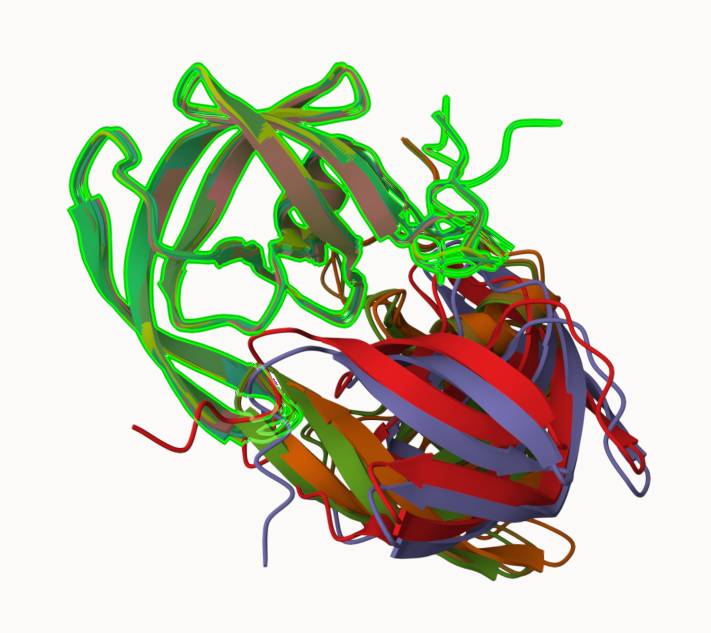

and the top ranked model colored by chain.

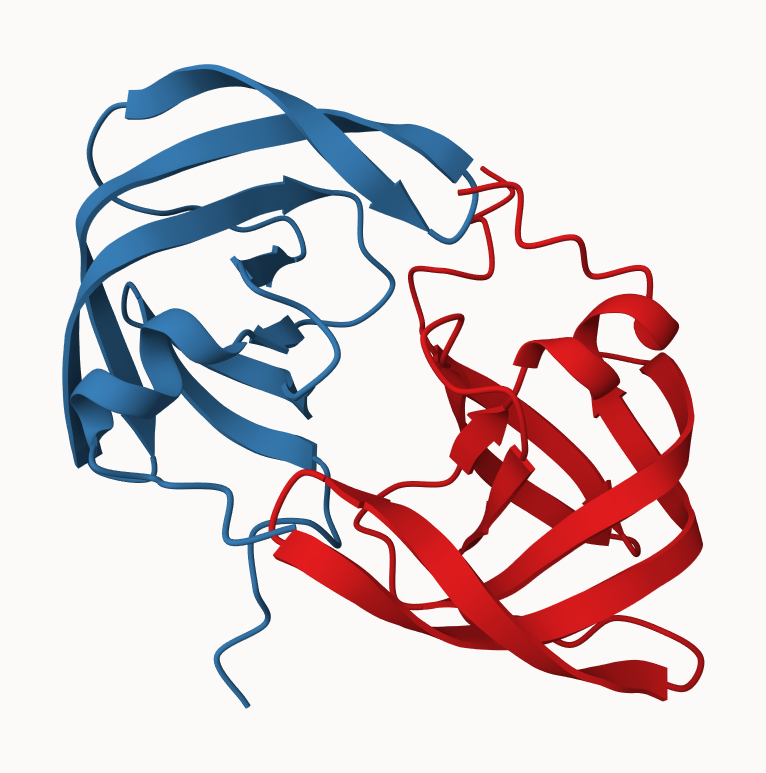

pLDDT score for model 1

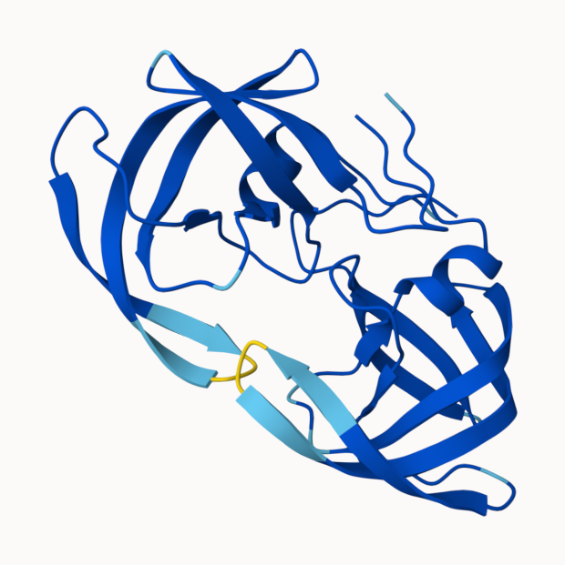

and model 5

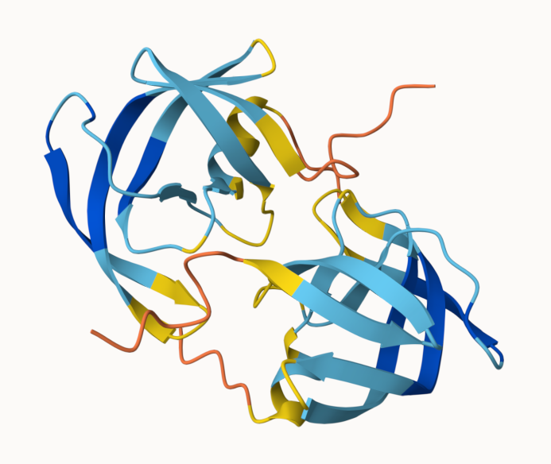

# Custom analysis of resulting models in R

Read key result files into R. The first thing I need to know is what my results directory/folder is called (i.e. it name is different for every AlphaFold run/job)

```r
results_dir <- "hivprdimer_23119:"
# File names for all PDB models
pdb_files <- list.files(path=results_dir,
                        pattern=".pdb",
                        full.names = TRUE)

# Print our PDB file names
basename(pdb_files)
```

```
## [1] "HIVPR_dimer_23119_unrelaxed_rank_001_alphafold2_multimer_v3_model_4_seed_000.pdb"
## [2] "HIVPR_dimer_23119_unrelaxed_rank_002_alphafold2_multimer_v3_model_1_seed_000.pdb"
## [3] "HIVPR_dimer_23119_unrelaxed_rank_003_alphafold2_multimer_v3_model_5_seed_000.pdb"
## [4] "HIVPR_dimer_23119_unrelaxed_rank_004_alphafold2_multimer_v3_model_2_seed_000.pdb"
## [5] "HIVPR_dimer_23119_unrelaxed_rank_005_alphafold2_multimer_v3_model_3_seed_000.pdb"
```

```r
library(bio3d)

m1 <- read.pdb(pdb_files[1])
m1
```

```
##
##  Call:  read.pdb(file = pdb_files[1])
##
##    Total Models#: 1
##      Total Atoms#: 1514,  XYZs#: 4542  Chains#: 2  (values: A B)
##
##      Protein Atoms#: 1514  (residues/Calpha atoms#: 198)
##      Nucleic acid Atoms#: 0  (residues/phosphate atoms#: 0)
##
##      Non-protein/nucleic Atoms#: 0  (residues: 0)
##      Non-protein/nucleic resid values: [ none ]
##
##    Protein sequence:
##       PQITLWQRPLVTIKIGGQLKEALLDTGADDTVLEEMSLPGRWKPKMIGGIGGFIKVRQYD
##       QILIEICGHKAIGTVLVGPTPVNIIGRNLLTQIGCTLNFPQITLWQRPLVTIKIGGQLKE
##       ALLDTGADDTVLEEMSLPGRWKPKMIGGIGGFIKVRQYDQILIEICGHKAIGTVLVGPTP
##       VNIIGRNLLTQIGCTLNF
##
## + attr: atom, xyz, calpha, call
```

```r
# Read all data from Models
#  and superpose/fit coords
pdbs <- pdbaln(pdb_files, fit=TRUE, exefile="msa")
```

```
## Reading PDB files:
## hivprdimer_23119:/HIVPR_dimer_23119_unrelaxed_rank_001_alphafold2_multimer_v3_model_4_seed_000.pdb
## hivprdimer_23119:/HIVPR_dimer_23119_unrelaxed_rank_002_alphafold2_multimer_v3_model_1_seed_000.pdb
## hivprdimer_23119:/HIVPR_dimer_23119_unrelaxed_rank_003_alphafold2_multimer_v3_model_5_seed_000.pdb
## hivprdimer_23119:/HIVPR_dimer_23119_unrelaxed_rank_004_alphafold2_multimer_v3_model_2_seed_000.pdb
## hivprdimer_23119:/HIVPR_dimer_23119_unrelaxed_rank_005_alphafold2_multimer_v3_model_3_seed_000.pdb
## .....
##
## Extracting sequences
##
## pdb/seq: 1   name: hivprdimer_23119:/HIVPR_dimer_23119_unrelaxed_rank_001_alphafold2_multimer_v3_model_4_seed_000.pdb
## pdb/seq: 2   name: hivprdimer_23119:/HIVPR_dimer_23119_unrelaxed_rank_002_alphafold2_multimer_v3_model_1_seed_000.pdb
## pdb/seq: 3   name: hivprdimer_23119:/HIVPR_dimer_23119_unrelaxed_rank_003_alphafold2_multimer_v3_model_5_seed_000.pdb
## pdb/seq: 4   name: hivprdimer_23119:/HIVPR_dimer_23119_unrelaxed_rank_004_alphafold2_multimer_v3_model_2_seed_000.pdb
## pdb/seq: 5   name: hivprdimer_23119:/HIVPR_dimer_23119_unrelaxed_rank_005_alphafold2_multimer_v3_model_3_seed_000.pdb
```

```r
rd <- rmsd(pdbs, fit=T)
range(rd)
```

```
## [1]  0.000 14.929
```

```r
# Read a reference PDB structure
pdb <- read.pdb("1hsg")
```

```
##   Note: Accessing on-line PDB file
```

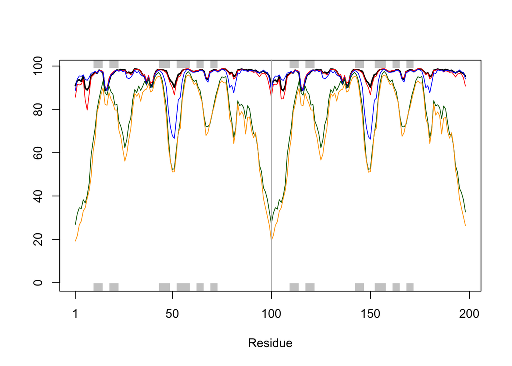

```r
plotb3(pdbs$b[1,], typ="l", lwd=2, sse=pdb)
points(pdbs$b[2,], typ="l", col="red")
points(pdbs$b[3,], typ="l", col="blue")
points(pdbs$b[4,], typ="l", col="darkgreen")
points(pdbs$b[5,], typ="l", col="orange")
abline(v=100, col="gray")
```

```r
core <- core.find(pdbs)
```

[output not shown]

[output cut: 59 more lines]

```
##  core size 98 of 198  vol = 10.314
##  core size 97 of 198  vol = 8.903
##  core size 96 of 198  vol = 7.455
##  core size 95 of 198  vol = 5.843
##  core size 94 of 198  vol = 4.517
##  core size 93 of 198  vol = 3.186
##  core size 92 of 198  vol = 2.696
##  core size 91 of 198  vol = 2.119
##  core size 90 of 198  vol = 1.701
##  core size 89 of 198  vol = 1.259
##  core size 88 of 198  vol = 0.862
##  core size 87 of 198  vol = 0.636
##  core size 86 of 198  vol = 0.526
##  core size 85 of 198  vol = 0.448
##  FINISHED: Min vol ( 0.5 ) reached
```

```r
core.inds <- print(core, vol=0.5)
```

```
## # 86 positions (cumulative volume <= 0.5 Angstrom^3)
##   start end length
## 1     8  48     41
## 2    50  50      1
## 3    52  95     44
```

```r
xyz <- pdbfit(pdbs, core.inds, outpath="corefit_structures")
```

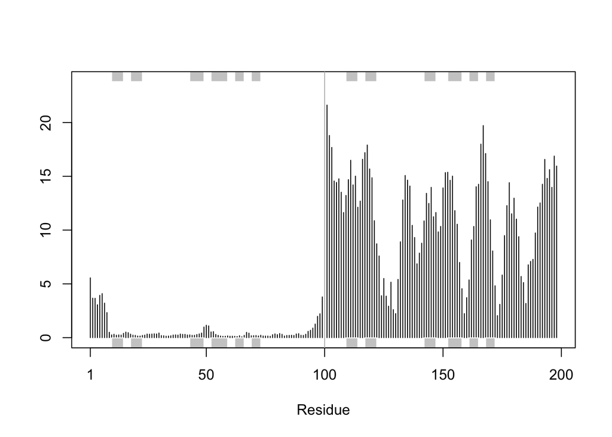

```r
rf <- rmsf(xyz)


plotb3(rf, sse=pdb)
abline(v=100, col="gray", ylab="RMSF")
```

```r
# Read alignment
aln_file <- list.files(path = results_dir,
                       pattern = ".a3m$",
                       full.names = TRUE)
aln <- read.fasta(aln_file[1], to.upper = TRUE)
```

```
## [1] " ** Duplicated sequence id's: 101 **"
## [2] " ** Duplicated sequence id's: 101 **"
```

```r
sim <- conserv(aln)
```

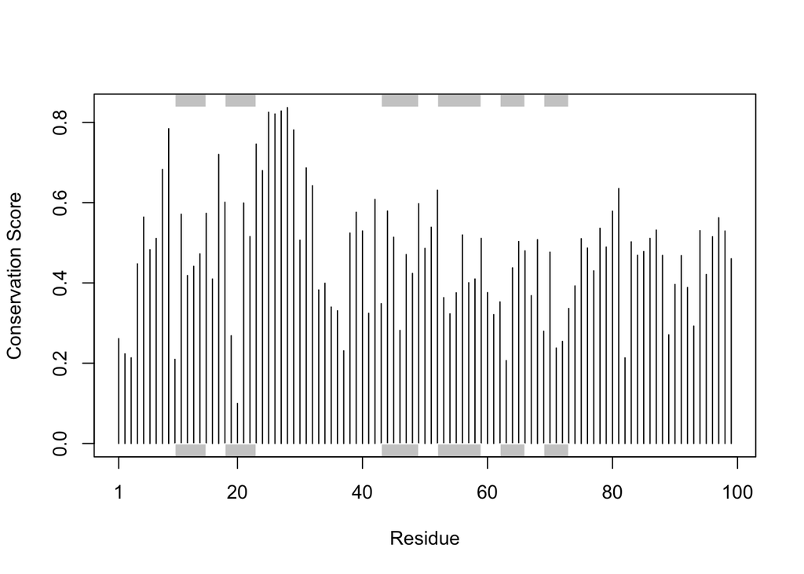

```r
plotb3(sim[1:99],
       sse=trim.pdb(pdb, chain="A"),
       ylab="Conservation Score")
```

```r
head(m1$atom)
```

```
##   type eleno elety  alt resid chain resno insert      x      y      z o     b
## 1 ATOM     1     N <NA>   PRO     A     1   <NA> 16.938 -3.990 -6.129 1 90.94
## 2 ATOM     2    CA <NA>   PRO     A     1   <NA> 16.938 -2.557 -6.430 1 90.94
## 3 ATOM     3     C <NA>   PRO     A     1   <NA> 16.438 -1.707 -5.266 1 90.94
## 4 ATOM     4    CB <NA>   PRO     A     1   <NA> 15.992 -2.449 -7.629 1 90.94
## 5 ATOM     5     O <NA>   PRO     A     1   <NA> 15.836 -2.232 -4.324 1 90.94
## 6 ATOM     6    CG <NA>   PRO     A     1   <NA> 15.070 -3.623 -7.496 1 90.94
##   segid elesy charge
## 1  <NA>     N   <NA>
## 2  <NA>     C   <NA>
## 3  <NA>     C   <NA>
## 4  <NA>     C   <NA>
## 5  <NA>     O   <NA>
## 6  <NA>     C   <NA>
```

```r
m1$atom$b[m1$calpha]
```

```
##   [1] 90.94 93.31 93.69 92.94 95.38 89.75 88.94 90.50 95.50 96.31 97.00 96.75
##  [13] 98.12 97.75 96.69 88.62 89.31 92.75 95.75 96.38 97.50 98.19 98.00 98.44
##  [25] 98.12 98.31 96.81 97.19 96.69 97.31 98.69 98.56 98.31 97.62 95.88 95.06
##  [37] 91.81 94.69 90.56 91.62 96.12 97.94 98.44 98.44 98.31 97.94 97.69 95.00
##  [49] 93.31 92.38 90.12 93.50 96.12 96.56 97.88 98.56 98.69 98.75 98.06 97.62
##  [61] 97.44 97.75 97.75 98.25 98.31 97.56 94.19 93.88 97.38 97.81 98.31 98.25
##  [73] 97.38 98.06 98.62 98.75 98.50 97.62 96.69 97.06 95.25 95.69 98.12 98.31
##  [85] 98.62 98.25 98.38 98.06 98.38 98.25 97.75 98.06 97.38 96.81 97.31 97.75
##  [97] 97.00 96.62 95.25 90.75 93.19 93.50 92.62 95.31 89.44 88.56 90.75 95.75
## [109] 96.31 97.00 96.81 98.12 97.69 96.62 88.50 89.25 92.75 95.81 96.31 97.44
## [121] 98.12 97.94 98.44 98.06 98.31 96.81 97.19 96.69 97.25 98.62 98.56 98.31
## [133] 97.56 95.81 95.00 91.75 94.62 90.50 91.62 96.06 97.94 98.44 98.44 98.31
## [145] 97.81 97.56 94.94 93.06 92.12 90.31 93.69 96.06 96.31 97.75 98.50 98.69
## [157] 98.75 98.00 97.56 97.44 97.69 97.75 98.25 98.31 97.56 94.31 93.88 97.38
## [169] 97.81 98.31 98.25 97.38 98.06 98.62 98.75 98.44 97.50 96.44 96.88 95.12
## [181] 95.56 98.06 98.25 98.62 98.25 98.38 98.06 98.44 98.25 97.75 98.06 97.38
## [193] 96.81 97.38 97.75 96.94 96.62 95.31
```

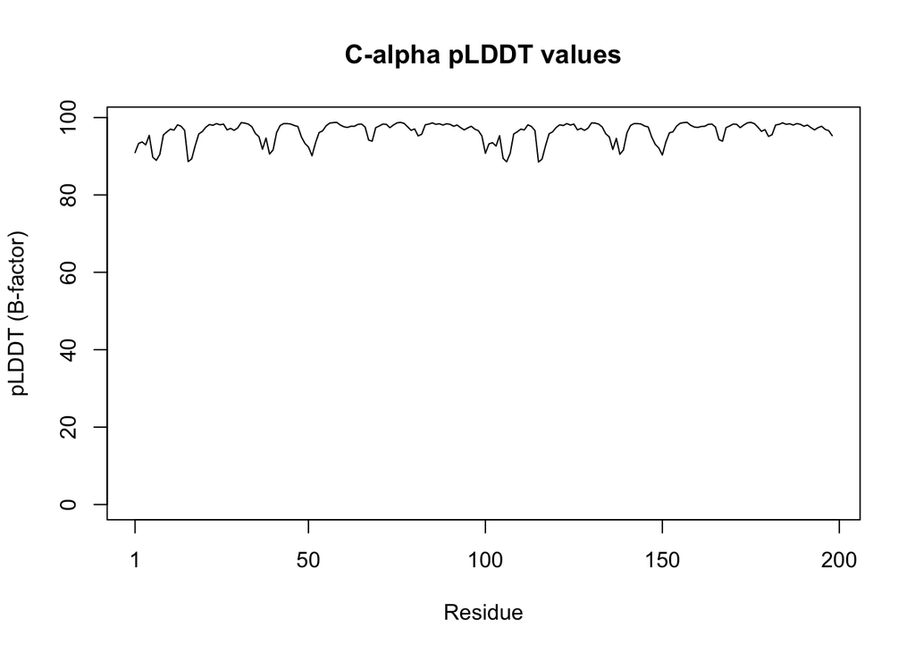

```r
plotb3(m1$atom$b[m1$calpha],
       typ = "l",
       ylab = "pLDDT (B-factor)",
       main = "C-alpha pLDDT values")
```

## Residue conservation from alignmnet file

```r
aln_file <- list.files(path=results_dir,
                       pattern=".a3m$",
                       full.names = TRUE)
```

Read this into R

```r
aln <- read.fasta(aln_file[1], to.upper = TRUE)
```

```
## [1] " ** Duplicated sequence id's: 101 **"
## [2] " ** Duplicated sequence id's: 101 **"
```

How many sequences are in this alignment

```r
dim(aln$ali)
```

```
## [1] 5397  132
```

We can score residue conservation in the alignment with the conserv() function.

```r
sim <- conserv(aln)
```

```r
con <- consensus(aln, cutoff = 0.9)
con$seq
```

```
##   [1] "-" "-" "-" "-" "-" "-" "-" "-" "-" "-" "-" "-" "-" "-" "-" "-" "-" "-"
##  [19] "-" "-" "-" "-" "-" "-" "D" "T" "G" "A" "-" "-" "-" "-" "-" "-" "-" "-"
##  [37] "-" "-" "-" "-" "-" "-" "-" "-" "-" "-" "-" "-" "-" "-" "-" "-" "-" "-"
##  [55] "-" "-" "-" "-" "-" "-" "-" "-" "-" "-" "-" "-" "-" "-" "-" "-" "-" "-"
##  [73] "-" "-" "-" "-" "-" "-" "-" "-" "-" "-" "-" "-" "-" "-" "-" "-" "-" "-"
##  [91] "-" "-" "-" "-" "-" "-" "-" "-" "-" "-" "-" "-" "-" "-" "-" "-" "-" "-"
## [109] "-" "-" "-" "-" "-" "-" "-" "-" "-" "-" "-" "-" "-" "-" "-" "-" "-" "-"
## [127] "-" "-" "-" "-" "-" "-"
```

```r
m1.pdb <- read.pdb(pdb_files[1])
occ <- vec2resno(c(sim[1:99], sim[1:99]), m1.pdb$atom$resno)
write.pdb(m1.pdb, o=occ, file="m1_conserv.pdb")
```